# Question

Un administrador de un centro cultural está analizando los datos de asistentes por función registrados en 10 salas diferentes durante la última semana. Los datos recopilados se muestran en la siguiente tabla:

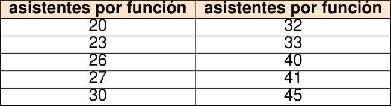

El administrador necesita calcular la mediana de estos datos para su informe semanal. Cuatro analistas han propuesto diferentes afirmaciones sobre cuál es la mediana y cómo se calcula.

**¿Cuál de las siguientes afirmaciones es CORRECTA y está BIEN JUSTIFICADA matemáticamente?**

## Answerlist

- La mediana es 20 porque es uno de los valores extremos del conjunto
- La mediana es 20 porque no hay valores repetidos, entonces se toma el menor
- La mediana es 62 porque se suman los dos valores centrales sin dividir
- La mediana es 31 porque es el promedio de los dos valores centrales (30 y 32)

# Solution

Para resolver este problema de **argumentación matemática**, debemos evaluar cada afirmación y determinar cuál está correctamente justificada según las propiedades de la mediana.

**Datos ordenados:** 20, 23, 26, 27, 30, 32, 33, 40, 41, 45

**Análisis de la mediana:**

Como tenemos 10 datos (número **par**), la mediana es el promedio de los dos valores centrales.

Posiciones centrales: 5 y 6

Valores centrales: 30 y 32

Mediana = ( 30 + 32 ) ÷ 2 = 31

**Evaluación de las afirmaciones:**

La afirmación correcta es: **“La mediana es 31 porque es el promedio de los dos valores centrales (30 y 32)”**

**¿Por qué es correcta?**

- Aplica correctamente la definición de mediana
- Utiliza el procedimiento matemático apropiado según el número de datos
- La justificación es coherente con las propiedades estadísticas

**¿Por qué las otras afirmaciones son incorrectas?**

- Confunden conceptos estadísticos (media, moda, mediana)
- Aplican procedimientos incorrectos
- No siguen las reglas matemáticas establecidas para el cálculo de la mediana

## Answerlist

- Falso
- Falso
- Falso
- Verdadero

# Meta-information

exname: mediana_argumentacion_estadistica extype: schoice exsolution: 0001 exshuffle: TRUE exsection: Argumentación en Estadística